# Grip strength, mating success, and immune function in US adults: a registered report

C. B. Smith and E. H. Hagen

03/23/2023

EHB Research Report

##Abstract

Evidence suggests that the mating benefits of muscle mass in human males trade off with costs of increased energy intake and decreased measures of native immunity, likely due to an evolutionary history of sexual selection. It is unknown if females experience a similar tradeoff. Using data from the 2011-2012 phase of the National Health and Nutrition Examination Survey, a large representative sample of the US, we will test whether grip strength, a proxy for upper body strength, is a positive predictor of self-reported outcome measures of adult mating success (lifetime number of sexual partners, past year number of sexual partners, and age at first intercourse) in both males and females, and negatively related to a measure of native immune function, white blood cell count, controlling for numerous anthropometric, socioeconomic, hormone, health, and physical activity related confounds. These results replicate an earlier study of US males. However, there was either no significant sex difference in the effect of grip strength, or the effect in females was smaller than males but still positive, evidence that a similar trade off in the costs and benefits of muscle exists for women.

**Table 1. Participant Characteristics**

| **Variable** | **N** | **Overall**, N = 4,192<sup>1</sup> | **Sex** **male**, N = 2,077<sup>1</sup> | **Sex** **female**, N = 2,115<sup>1</sup> | **p-value**<sup>2</sup> |  |
| --- | --- | --- | --- | --- | --- | --- |
| Age (Years) | 4,192 | 38.01 (12.73) | 37.72 (12.85) | 38.29 (12.61) |  | 0.14 |
| Race and Ethnicity | 4,192 |  |  |  | 0.049 |  |
| MexicanAmerican |  | 477 / 4,192 (11%) | 251 / 2,077 (12%) | 226 / 2,115 (11%) |  |  |
| OtherHispanic |  | 429 / 4,192 (10%) | 194 / 2,077 (9.3%) | 235 / 2,115 (11%) |  |  |
| NonHispanicWhite |  | 1,389 / 4,192 (33%) | 714 / 2,077 (34%) | 675 / 2,115 (32%) |  |  |
| NonHispanicBlack |  | 1,107 / 4,192 (26%) | 525 / 2,077 (25%) | 582 / 2,115 (28%) |  |  |
| NonHispanicAsian |  | 655 / 4,192 (16%) | 318 / 2,077 (15%) | 337 / 2,115 (16%) |  |  |
| OtherRace |  | 135 / 4,192 (3.2%) | 75 / 2,077 (3.6%) | 60 / 2,115 (2.8%) |  |  |
| Combined Grip Strength | 3,607 | 75.31 (22.13) | 91.79 (17.38) | 58.36 (10.76) | <0.001 |  |
| Missing |  | 585 | 249 | 336 |  |  |
| BMI (kg/m^2) | 3,993 | 28.59 (7.14) | 28.11 (6.35) | 29.06 (7.81) | 0.015 |  |
| Missing |  | 199 | 96 | 103 |  |  |
| Partnered Status | 3,886 |  |  |  | 0.12 |  |
| FALSE |  | 1,676 / 3,886 (43%) | 804 / 1,920 (42%) | 872 / 1,966 (44%) |  |  |
| TRUE |  | 2,210 / 3,886 (57%) | 1,116 / 1,920 (58%) | 1,094 / 1,966 (56%) |  |  |
| Missing |  | 306 | 157 | 149 |  |  |
| Education | 4,192 |  |  |  | <0.001 |  |
| 1 |  | 259 / 4,192 (6.2%) | 137 / 2,077 (6.6%) | 122 / 2,115 (5.8%) |  |  |
| 2 |  | 633 / 4,192 (15%) | 339 / 2,077 (16%) | 294 / 2,115 (14%) |  |  |
| 3 |  | 889 / 4,192 (21%) | 486 / 2,077 (23%) | 403 / 2,115 (19%) |  |  |
| 4 |  | 1,337 / 4,192 (32%) | 627 / 2,077 (30%) | 710 / 2,115 (34%) |  |  |
| 5 |  | 1,074 / 4,192 (26%) | 488 / 2,077 (23%) | 586 / 2,115 (28%) |  |  |
| Height (cm) | 3,998 | 168.29 (9.93) | 175.01 (7.51) | 161.66 (7.20) | <0.001 |  |
| Missing |  | 194 | 94 | 100 |  |  |
| Weight (kg) | 3,995 | 81.16 (22.11) | 86.36 (21.46) | 76.04 (21.55) | <0.001 |  |
| Missing |  | 197 | 95 | 102 |  |  |
| WBCC (1000 cells/µL) | 3,838 | 7.00 (2.10) | 6.90 (2.07) | 7.10 (2.13) | 0.006 |  |
| Missing |  | 354 | 185 | 169 |  |  |
| Testosterone (ng/dL) | 3,695 | 219.33 (233.15) | 417.14 (178.67) | 25.65 (22.28) | <0.001 |  |
| Missing |  | 497 | 249 | 248 |  |  |

<sup>1</sup> Mean (SD); n / N (%)  
<sup>2</sup> Wilcoxon rank sum test; Pearson's Chi-squared test

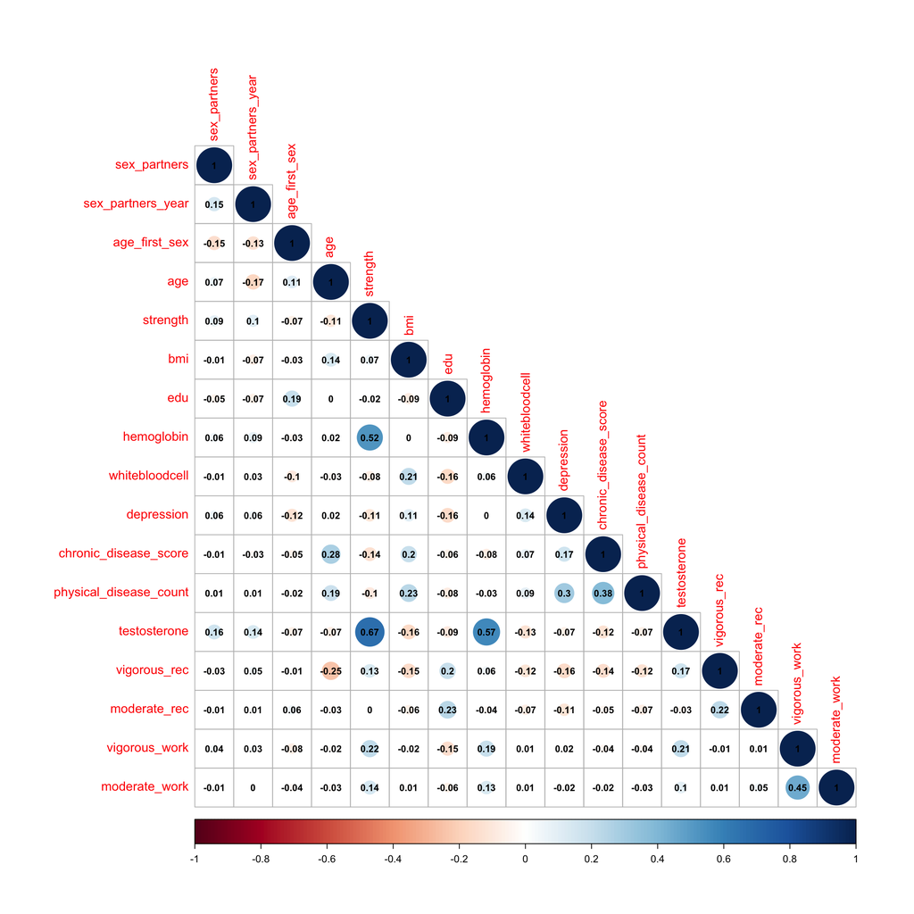

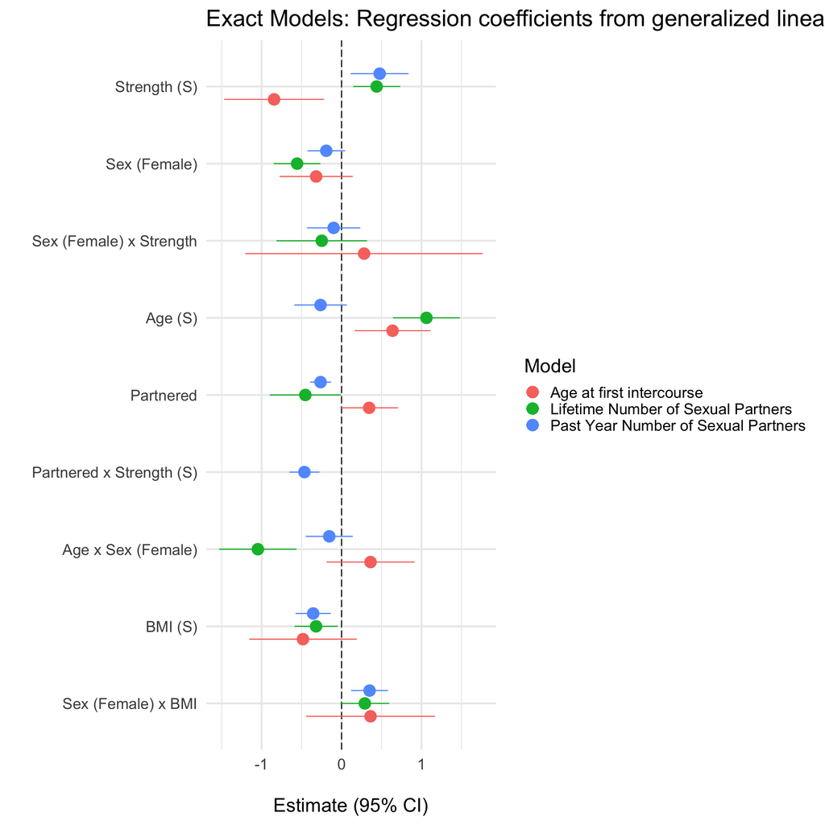

```
## ✖ `edu` and `total_work_MET` terms have not been found in `x`.
```

Table 2. Exact Models of Mating Success

Standardized regression coefficents from generalized linear models for three indices of mating success for men and women ages 18-59. Models derived from Lassek and Gaulin 2009

| **Variable** | Lifetime number of sexual partners **Beta (SE)**<sup>1,2</sup> | Past year number of sexual partners **Beta (SE)**<sup>1,2</sup> | Age at first sexual intercourse **Beta (SE)**<sup>1,2</sup> |
| --- | --- | --- | --- |
| Age | 1.1*** (0.213) | -0.26 (0.167) | 0.64* (0.242) |
| Sex |  |  |  |
| male | — | — | — |
| female | -0.56** (0.149) | -0.19 (0.120) | -0.32 (0.233) |
| Grip strength | 0.44* (0.150) | 0.48* (0.185) | -0.84* (0.319) |
| Currently partnered |  |  |  |
| FALSE | — | — | — |
| TRUE | -0.45 (0.227) | -0.26** (0.067) | 0.35 (0.184) |
| BMI | -0.32* (0.138) | -0.36* (0.112) | -0.48 (0.343) |
| Age * Sex |  |  |  |
| Age * female | -1.0** (0.247) | -0.15 (0.150) | 0.36 (0.282) |
| Sex * Grip strength |  |  |  |
| female * Grip strength | -0.25 (0.289) | -0.10 (0.170) | 0.28 (0.757) |
| Sex * BMI |  |  |  |
| female * BMI | 0.29 (0.155) | 0.35* (0.118) | 0.36 (0.411) |
| Grip strength * Currently partnered |  |  |  |
| Grip strength * TRUE |  | -0.46** (0.096) |  |

<sup>1</sup> *p<0.05; **p<0.01; ***p<0.001  
<sup>2</sup> SE = Standard Error

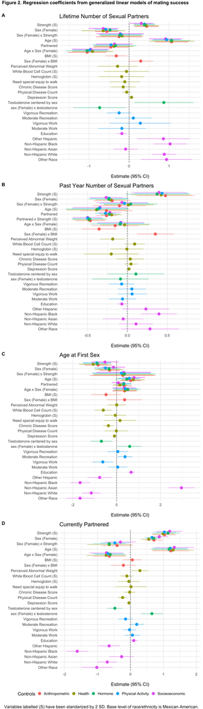

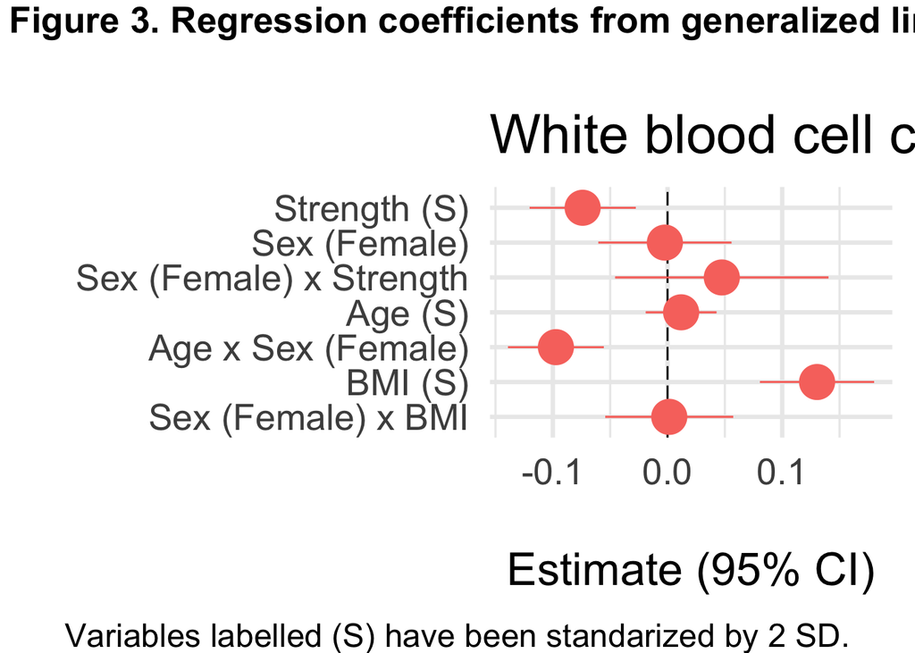

Regression coefficients for predictors of WBC count in men and women 18-59, exact model from lassek and gaulin

| **Variable** | **Beta (SE)**<sup>1,2</sup> |
| --- | --- |
| Age | 0.01 (0.016) |
| Sex |  |
| male | — |
| female | 0.00 (0.030) |
| Grip strength | -0.07* (0.024) |
| BMI | 0.13*** (0.025) |
| Age * Sex |  |
| Age * female | -0.10** (0.021) |
| Sex * Grip strength |  |
| female * Grip strength | 0.05 (0.047) |
| Sex * BMI |  |
| female * BMI | 0.00 (0.028) |

<sup>1</sup> *p<0.05; **p<0.01; ***p<0.001  
<sup>2</sup> SE = Standard Error